# ENERGY,96177

Pang Yi Hahn; Quan Qian Hui; Phuah Yi Shan Kristy; Karis Chua Xin Hui; Chow Hui Ming

2024-04-14

# Introduction

The data set we will be exploring is the Energy Data from the TidyTuesday repository, which comes from Our World in Data. The dataset includes data on energy consumption, carbon emissions and the different energy sources (TidyTuesday, n.d.).

Our question is **“Based on recent trends in the consumption of fossil fuels and renewable energy sources, can we achieve the global target of the Paris Agreement to reach net zero carbon emissions by 2050?”** (United Nations, n.d.). Global warming, which is caused by excessive emissions of greenhouse gases, is a pressing issue that needs to be addressed as it has caused an increased number of natural disasters and unusual weather phenomena in recent years. One of the largest contributors to greenhouse gas emissions is the burning of fossil fuels for energy, especially for the generation of electricity (United Nations, n.d.). Thus, we are interested to see if the Paris Agreement can be achieved by the set deadline through analysing the global trends in greenhouse gas emissions, energy consumption and electricity generation since 2000.

We will be making three graphs to address our question. First, a line graph is plotted to visualise the global trend of greenhouse gas emissions. Second, would be a bar graph showing the global consumption of fossil fuels and renewables. Finally, the last graph is an area chart showing the electricity generated from fossil fuels and renewables.

# Pre-Analysis Process

```r
# Loading Library
library(tidyverse)

# Reading Dataset
owid_energy <- readr::read_csv('https://raw.githubusercontent.com/rfordatascience/tidytuesday/master/data/2023/2023-06-06/owid-energy.csv')

# Primary Cleaning
owid_energy = owid_energy %>%
  filter(country == "World") %>%
  filter(year >= 2000)
```

# Graph 1: Greenhouse Gas Emmision

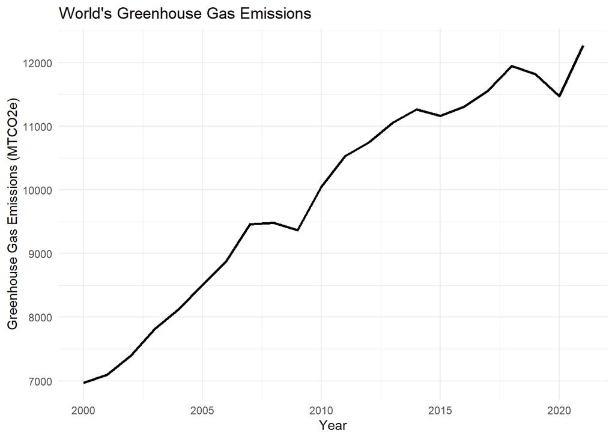

```r
# Selecting Important Data
data1 = owid_energy %>%
  select(country,year,greenhouse_gas_emissions)

# Plotting
graph1 = ggplot(data1,aes(x = year, y = greenhouse_gas_emissions)) +
  geom_line(size = 1) +
  labs(title = "World's Greenhouse Gas Emissions ", x = "Year", y = "Greenhouse Gas Emissions (MTCO2e)") +
  theme_minimal()

graph1
```

# Discussion for Graph 1

In Graph 1, a **line graph** has been plotted, showing a generally increasing trend of global gas emissions from 2000 to 2021. From the graph, there are 3 distinct dips, indicating a decrease in global greenhouse gas emissions. Around the year 2008-2009, there is a slight dip in global gas emissions, before increasing sharply after. This slight decrease could be due to the global financial crisis, in which global recession, falling global demand and high oil prices played a major role in reducing the rate of emissions (Clark, 2009). The dip around the year 2015 could be explained by the increase in clean energy development, such as the decrease of coal use in China, whose carbon dioxide emissions account for nearly one-third of global emissions and was largely responsible for the decline in global emissions. More than half of new energy needs in China were met in 2014 from non-fossil fuel sources, such as hydro, nuclear, wind and solar power (McKenna, 2015). The last dip occurred around 2020, where emissions plunged 4.6%, due to COVID-19 causing heavy lockdowns, restriction of global mobility, and hampering economic activity. However, global greenhouse gas emissions rebounded after 2020 to a new record of 6.4%, eclipsing pre-pandemic peak as global activity resumed (Bhaumati, 2022). This shows that current climate policies have not been effective in decreasing global emissions, and it will be extremely difficult to meet the targets of the Paris Agreement, based on current trends.

# Graph 2: Energy Consumption

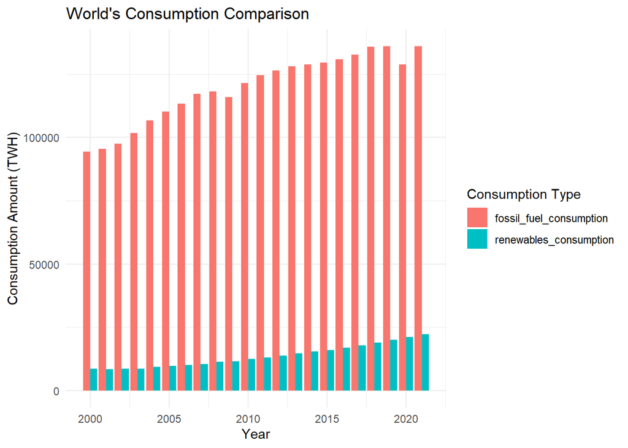

```r
# Selecting Important Data
data2 = owid_energy %>%
  select(country,year, fossil_fuel_consumption, renewables_consumption) %>%
  gather(`fossil_fuel_consumption`: `renewables_consumption`,key= "consumption_type",value="consumption_amount")

# Plotting
options(scipen = 999)
graph2 = ggplot(data2, aes(x=year , y=consumption_amount, fill= consumption_type)) +
  geom_col(position = position_dodge(width = 0.9)) +
  labs(x = "Year", y = "Consumption Amount (TWH)", fill="Consumption Type") +
  ggtitle("World's Consumption Comparison") +
  theme_minimal()

graph2
```

# Discussion for Graph 2

In Graph 2, a **grouped bar graph** is plotted, showing the trend of consumption of fossil fuels and renewables from 2000 to 2021. Based on the graph, both fossil fuels and renewables show an increasing trend. This shows that the level of consumption of fossil fuels is not affected by the level of consumption of renewables. Since renewables are seen as a replacement of fossil fuels in generating electricity, current policies have not been effective in decreasing the use of fossil fuels and encouraging the use of renewables.